# Exercises - Bayes Rules! 3

Braulio Güémez

28/9/2021

```r
library(bayesrules)
library(tidyverse)
library(ggplot2)
library(ggthemes)
```

## Exercise 3.1.

a

First, I created functions for each of the central tendency measures for the prior that are in the book

```r
 ## We'll need these functions
mean <- function(alfa,beta) {
  result <- alfa/(alfa+beta)
  return(result)
}

vari <- function(alfa,beta) {
  result <- alfa*beta/((alfa+beta)^2*(alfa+beta+1))
  return(result)
}

alfa <- function(mean) {
  result <- (mean)/(1-mean) ## assuming b=1
  return(result)
}
```

```r
1/alfa(.4)
```

```
## [1] 1.5
```

Now I know that beta is 1.5A. With this information I can try different values of alfa and beta. After many attempts I get to this conclusion:

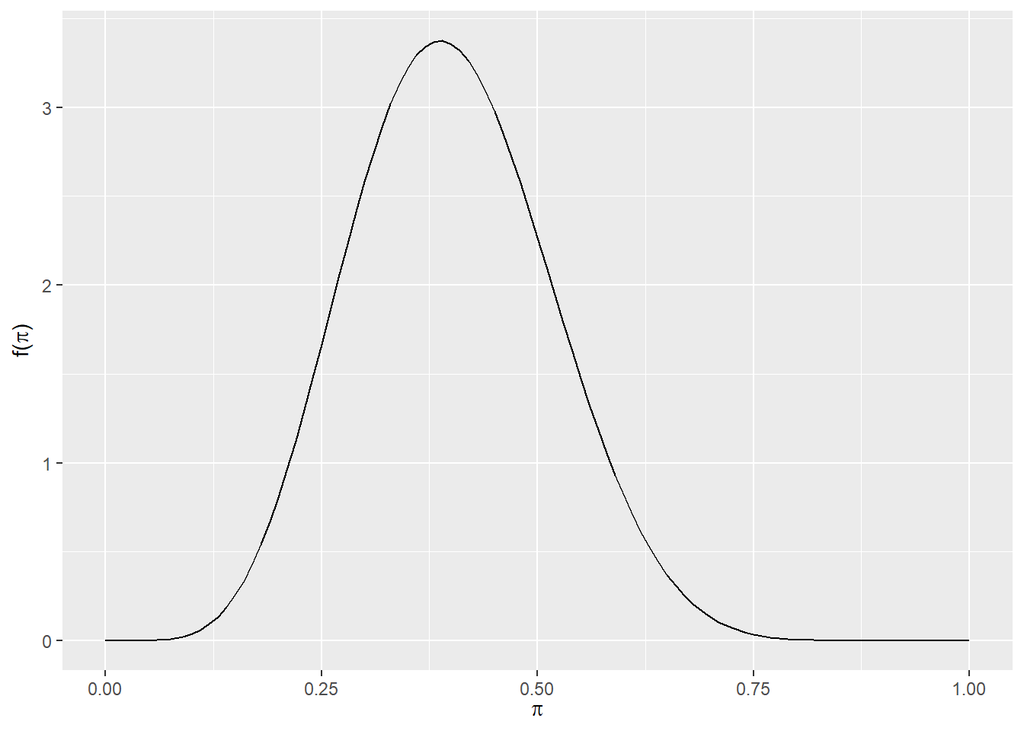

```r
plot_beta(7,10.5) ## We tune this beta distrtbution
```

```r
quantile(rbeta(1000, 7, 10.5), c(.05,.95)) ## It's very close to what we need
```

```
##        5%       95%
## 0.2172056 0.6020767
```

Or using Steve’s method:

```r
p <- .4
n <- 15

alpha <- p*n
beta <- n*(1-p)
quantile(rbeta(1000, alpha, beta), c(.05,.95))
```

```
##        5%       95%
## 0.2072816 0.6191667
```

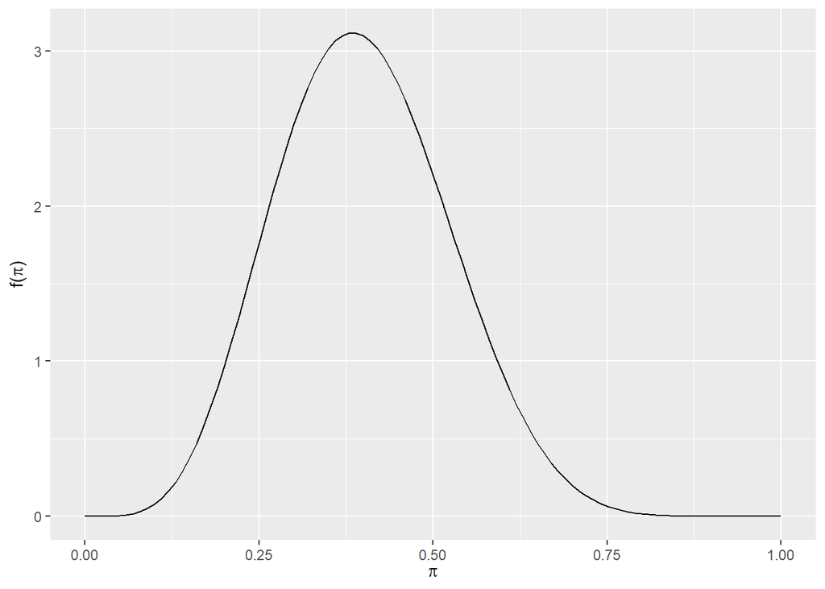

```r
plot_beta(alpha,beta) ## We tune this beta distrtbution
```

2. In this case, we can calculate the exact plot:

```r
alfa(.8)
```

```
## [1] 4
```

```r
# We know alfa equals 4 times B

b <- seq(0,100,.1)
a <- b*4
p <-  vari(a,b)
df <-  tibble(alfa=a, beta=b, p=p)

df |> filter(p>.05 & p<.059)
```

```
## # A tibble: 1 x 3
##    alfa  beta      p
##   <dbl> <dbl>  <dbl>
## 1   1.6   0.4 0.0533
```

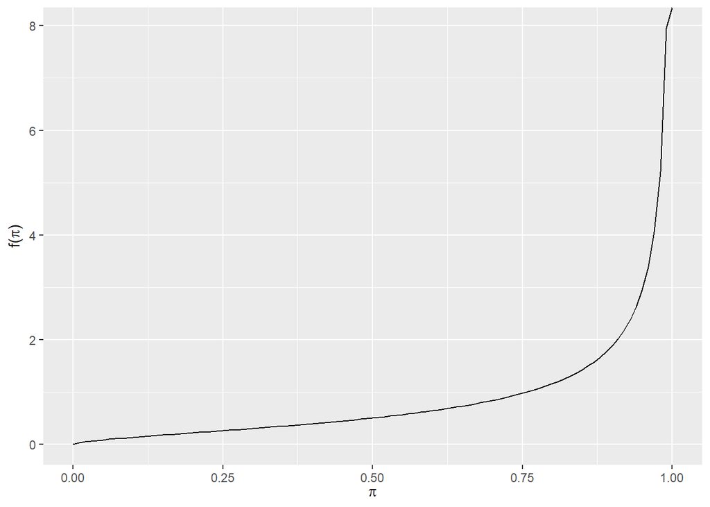

```r
plot_beta(1.6,.4)
```

```r
summarize_beta(1.6,.4)
```

```
##   mean mode        var        sd
## 1  0.8    1 0.05333333 0.2309401
```

3. Using Steve’s method:

```r
p <- .9
n <- 85

alpha <- p*n
beta <- n*(1-p)
quantile(rbeta(1000, alpha, beta), c(.05,.95))
```

```
##        5%       95%
## 0.8425345 0.9460850
```

```r
alpha
```

```
## [1] 76.5
```

```r
beta
```

```
## [1] 8.5
```

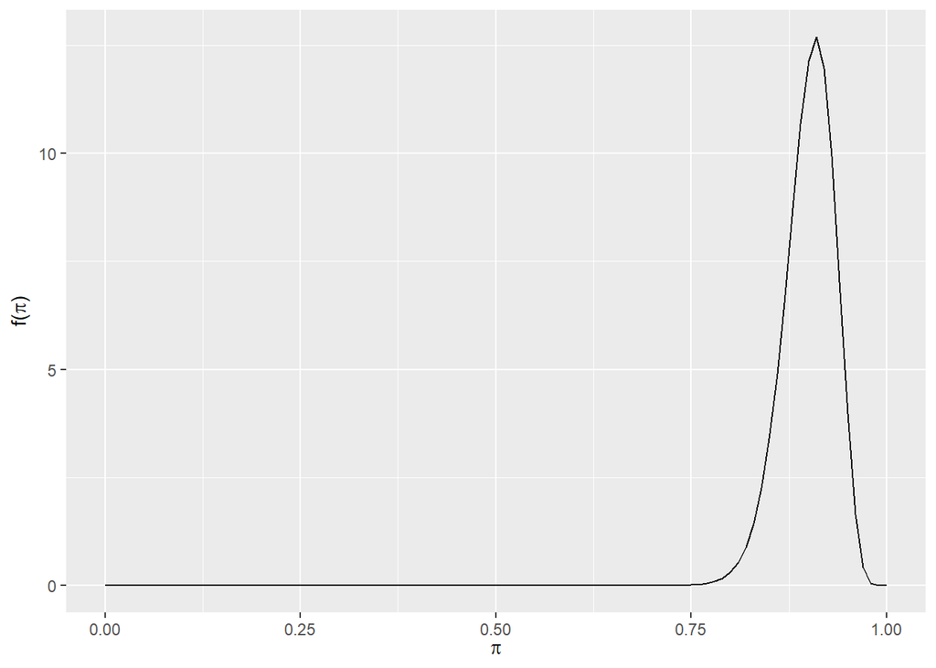

```r
plot_beta(alpha,beta)
```

4. It seems like is all or everything for Sal!

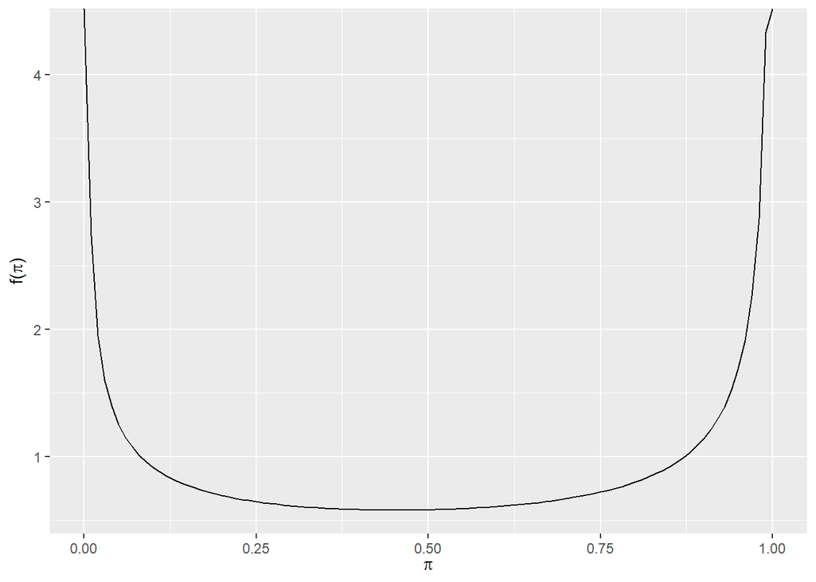

```r
plot_beta(.5,.4)
```

## Exercise 3.2.

Based on that information we can approximate a Beta model:

```r
alfa(.8)
```

```
## [1] 4
```

```r
## We know alfa is 4 times b, so
quantile(rbeta(1000, 40, 10), c(.05,.95)) ## Fairly close
```

```
##        5%       95%
## 0.6995348 0.8823642
```

```r
mean(40,10)
```

```
## [1] 0.8
```

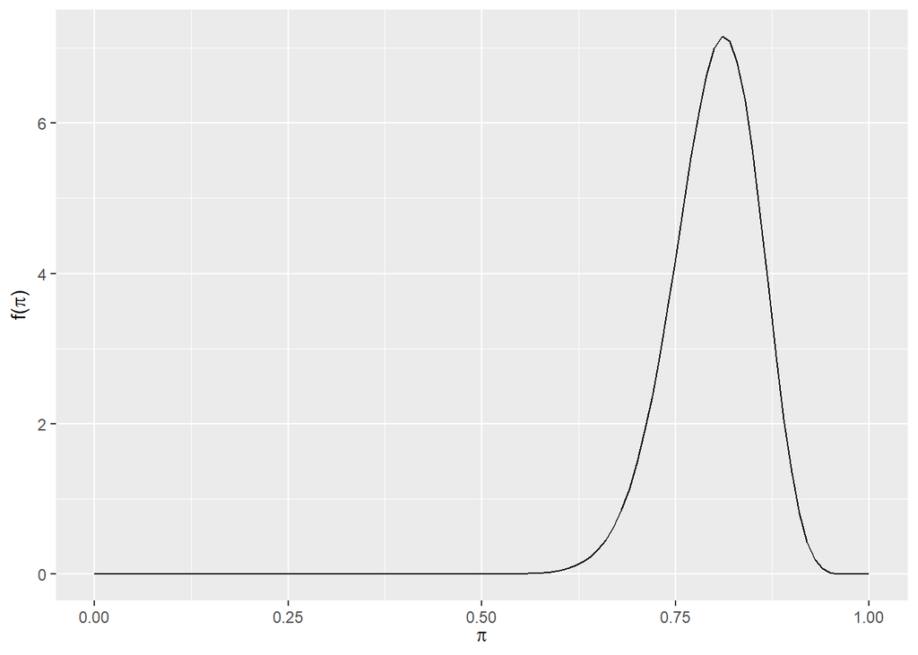

```r
plot_beta(40,10)
```

2. In this case, we can calculate the exact plot:

```r
alfa(.9)
```

```
## [1] 9
```

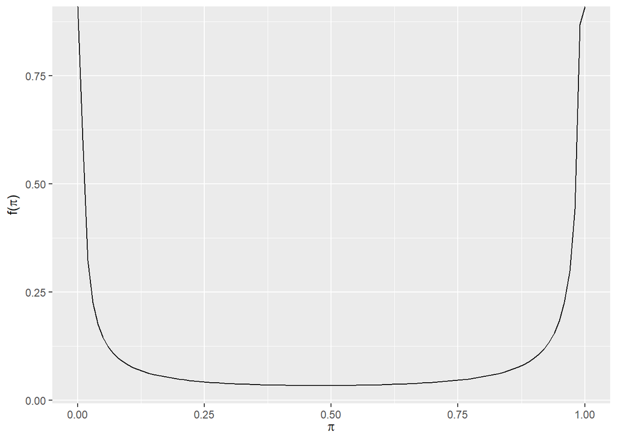

```r
## Alfa is 9 times Beta



b <- seq(0,100,.01)
a <- b*9
p <-  vari(a,b)
df <-  tibble(alfa=a, beta=b, p=p)

df_2 <- df |> filter(p>.079 & p<.089)


plot_beta(df_2$alfa,df_2$beta)
```

```r
summarize_beta(df_2$alfa,df_2$beta)
```

```
##   mean    mode        var        sd
## 1  0.9 0 and 1 0.08181818 0.2860388
```

3. Using Steve’s Method:

```r
p <- .85
n <- 45

alpha <- p*n
beta <- n*(1-p)
quantile(rbeta(1000, alpha, beta), c(.05,.95))
```

```
##        5%       95%
## 0.7576778 0.9239389
```

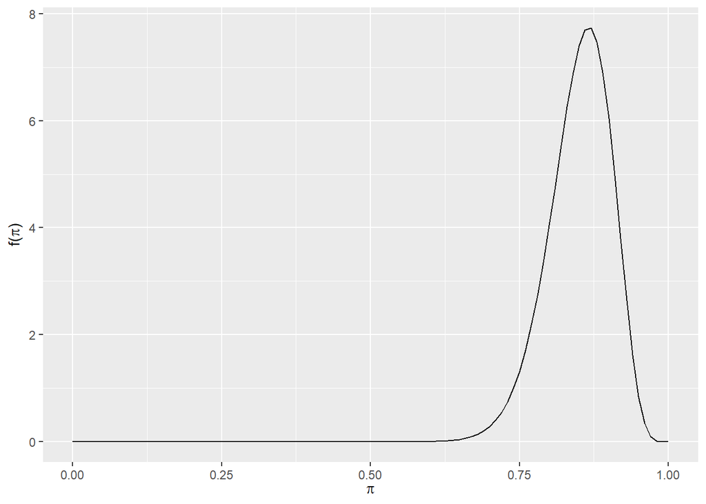

```r
plot_beta(alpha,beta)
```

4. Since he is not very sure, let us place the mode on .3 with a relatively high SD /

```r
## Mode ~ .3

## I need the mode function for this

moda <- function(alfa,beta) {
  result <- (alfa-1)/(alfa+beta-2)
  return(result)
}

moda(2,3.4)
```

```
## [1] 0.2941176
```

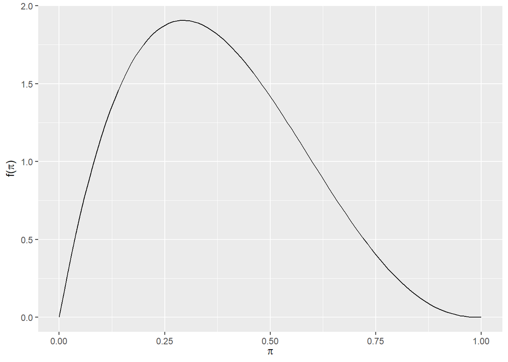

```r
plot_beta(2,3.4)
```

```r
summarize_beta(2,3.4)
```

```
##        mean      mode       var        sd
## 1 0.3703704 0.2941176 0.0364369 0.1908845
```

## Exercise 3.3

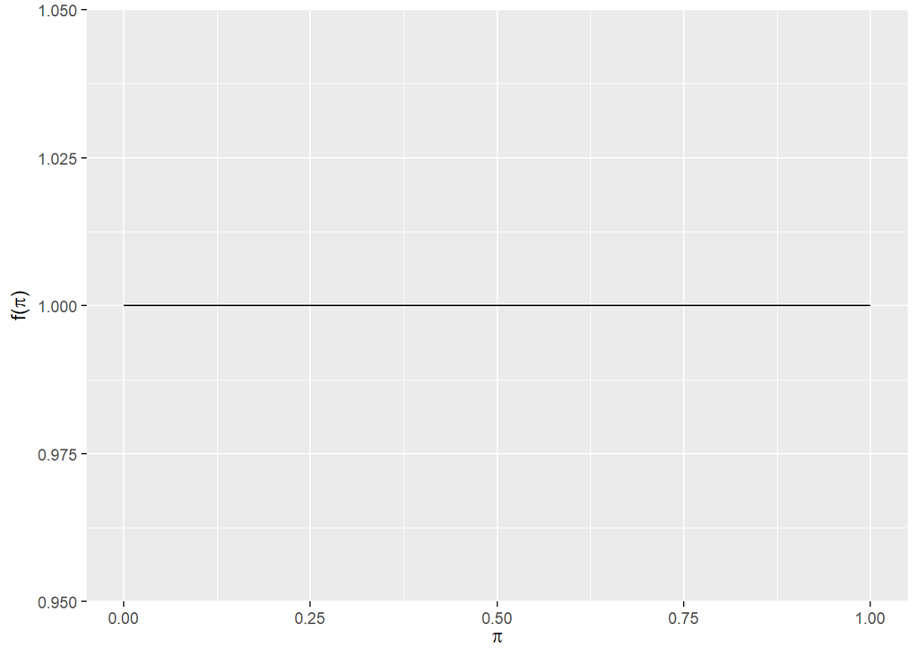

```r
plot_beta(1,1)
```

2. The mean is .5 because substituting the values of alpha and beta in (alfa/alfa+beta) equals .5. This makes sense because there is an a priori equal chance of being right or wrong. That is the frequentist philosophy.

```r
summarize_beta(1,1)
```

```
##   mean mode        var        sd
## 1  0.5  NaN 0.08333333 0.2886751
```

3. The SD (shown above) is .28

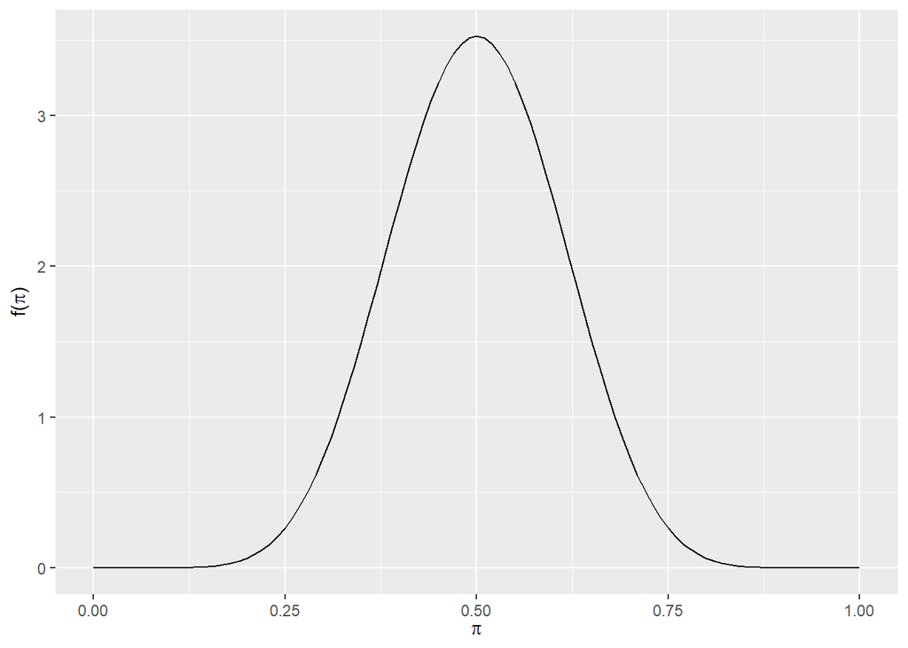

```r
plot_beta(10,10)
```

```r
summarize_beta(10,10)
```

```
##   mean mode        var        sd
## 1  0.5  0.5 0.01190476 0.1091089
```

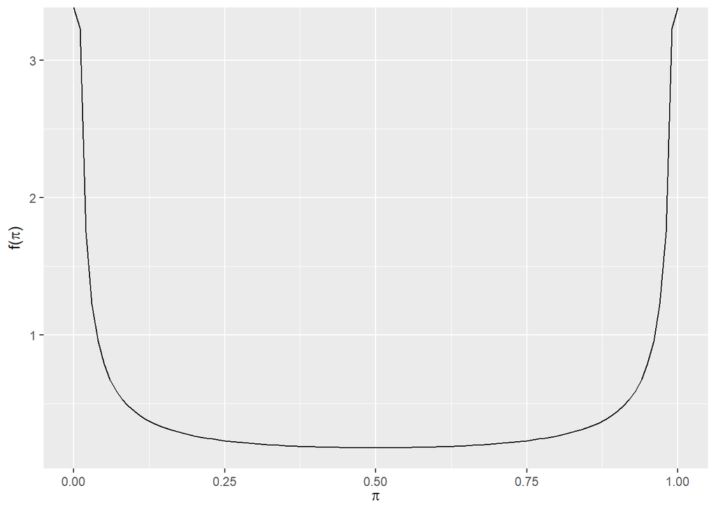

```r
plot_beta(.1,.10)
```

```r
summarize_beta(.10,.10)
```

```
##   mean    mode       var        sd
## 1  0.5 0 and 1 0.2083333 0.4564355
```

## Exercise 3.4

(Top left to right) Beta (.5,.5), Beta(2,2), Beta (6,2) (Bottom, left to right) Beta (1,1), Beta (.5,6) Beta (6,6)

Just to control my anxiety and be absolutely positive:

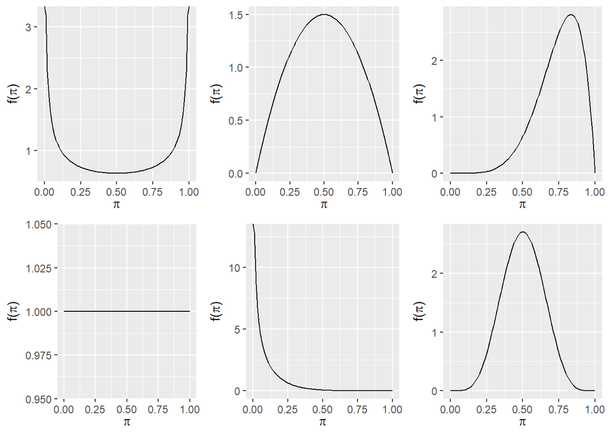

```r
library(ggpubr)

a <-plot_beta(.5,.5)
b <- plot_beta(2,2)
c <- plot_beta(6,2)
d <-  plot_beta(1,1)
e <- plot_beta(.5,6)
f <- plot_beta(6,6)

ggarrange(a,b,c,d,e,f, ncol=3,nrow=2)
```

## Exercise 3.5

(Top left to right) Beta (1,.3), Beta(3,3), Beta (4,2) (Bottom, left to right) Beta (2,1), Beta (5,6) Beta (6,3)

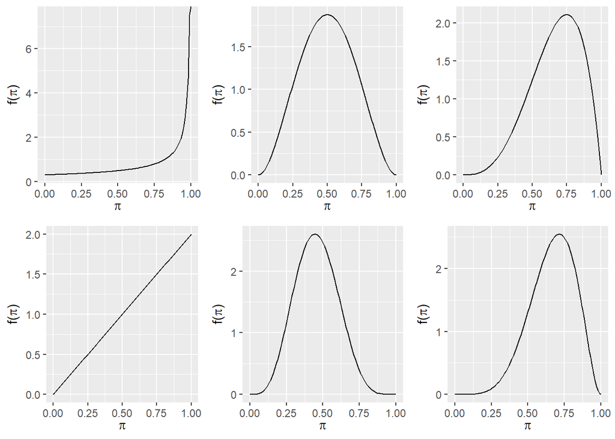

```r
a <-plot_beta(1,.3)
b <- plot_beta(3,3)
c <- plot_beta(4,2)
d <-  plot_beta(2,1)
e <- plot_beta(5,6)
f <- plot_beta(6,3)

ggarrange(a,b,c,d,e,f, ncol=3,nrow=2)
```

## Exercise 3.6

a Sorry for the long code, but I don’t see a cheaper way

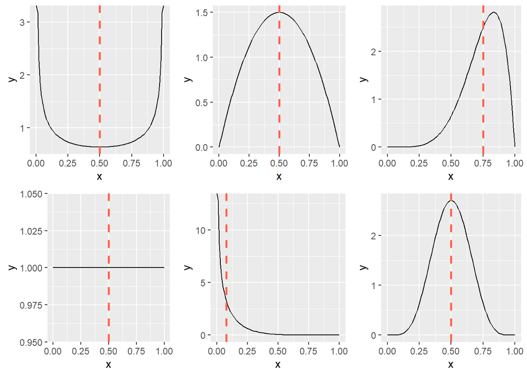

```r
alphas <- c(.5,2,6,1,.5,6)
alist <- as.list(alphas)
betas <- c(.5,2,2,1,6,6)
blist <- as.list(betas)
x <- seq(0,1,length.out=100)


plot_list = list()
for (i in 1:6){
    dfp <- tibble(x=x,y=dbeta(x,alist[[i]][1],blist[[i]][1]), m=mean(alist[[i]][1],blist[[i]][1]))

p <- dfp |> ggplot(aes(x,y)) + geom_line() + geom_vline(xintercept = dfp$m[1], linetype=2, color = "tomato", size=1)

      plot_list[[i]] <- p
  }

ggarrange(plot_list[[1]],
          plot_list[[2]],
          plot_list[[3]],
          plot_list[[4]],
          plot_list[[5]],
          plot_list[[6]], ncol=3,nrow=2)
```

Means are in dashed red lines. The smallest mean appears to be the model in the bottom and the middle, which corresponds to Beta(.5,6). The highest is the one from the top right plot, corresponding to Beta (6,2)

b Sorry for the long code, but I don’t see a cheaper way

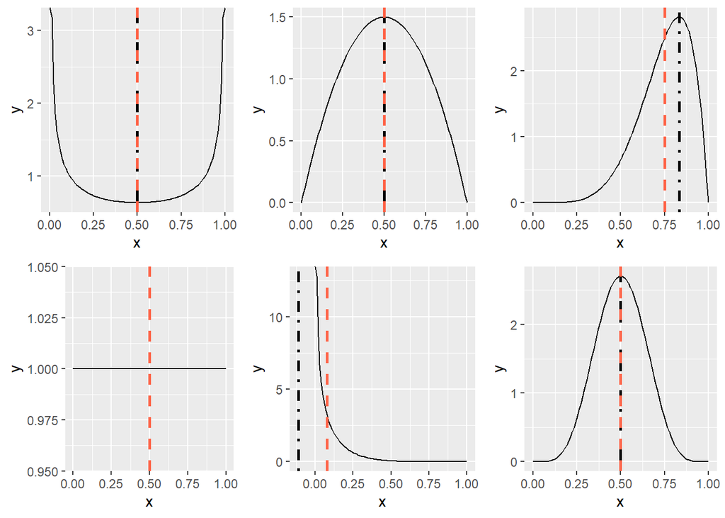

```r
alphas <- c(.5,2,6,1,.5,6)
alist <- as.list(alphas)
betas <- c(.5,2,2,1,6,6)
blist <- as.list(betas)
x <- seq(0,1,length.out=100)


plot_list = list()
for (i in 1:6){
    dfp <- tibble(x=x,y=dbeta(x,alist[[i]][1],blist[[i]][1]), m=moda(alist[[i]][1],blist[[i]][1]), prom=mean(alist[[i]][1],blist[[i]][1]))

p <- dfp |> ggplot(aes(x,y)) + geom_line() + geom_vline(xintercept = dfp$m[1], linetype=4, color = "black", size=1) + geom_vline(xintercept = dfp$prom[1], linetype=2, color = "tomato", size=1)

      plot_list[[i]] <- p
  }

ggarrange(plot_list[[1]],
          plot_list[[2]],
          plot_list[[3]],
          plot_list[[4]],
          plot_list[[5]],
          plot_list[[6]], ncol=3,nrow=2)
```

Means are in dashed red lines and modes in black. The smallest mode appears to be the model in the bottom and the middle, which corresponds to Beta(.5,6). The highest is the one from the top right plot, corresponding to Beta (6,2)

c

```r
alphas <- c(.5,2,6,1,.5,6)
betas <- c(.5,2,2,1,6,6)
x <- seq(0,1,length.out=100)
dfp <- tibble(a=alphas,b=betas,sd=vari(a,b)^(1/2))

dfp |> filter(sd==max(dfp$sd))
```

```
## # A tibble: 1 x 3
##       a     b    sd
##   <dbl> <dbl> <dbl>
## 1   0.5   0.5 0.354
```

Beta(.5,.5) is the model with the largest SD

```r
dfp |> filter(sd==min(dfp$sd))
```

```
## # A tibble: 1 x 3
##       a     b     sd
##   <dbl> <dbl>  <dbl>
## 1   0.5     6 0.0973
```

Beta(.5,6) is the model with the smallest SD

## Exercise 3.7

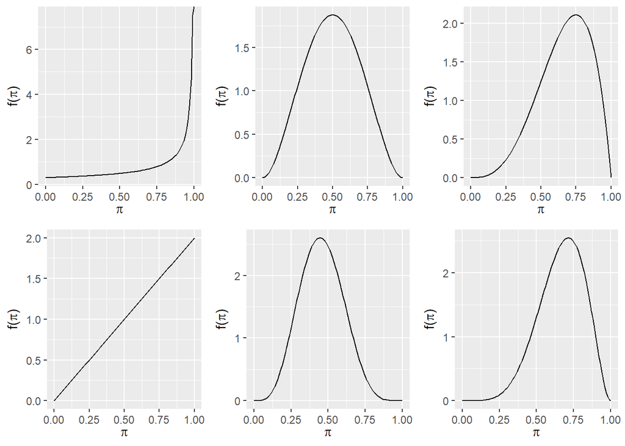

```r
a <-plot_beta(1,.3)
b <- plot_beta(3,3)
c <- plot_beta(4,2)
d <-  plot_beta(2,1)
e <- plot_beta(5,6)
f <- plot_beta(6,3)

ggarrange(a,b,c,d,e,f, ncol=3,nrow=2)
```

b.

```r
a <-summarize_beta(.5,.5)
b <- summarize_beta(1,1)
c <- summarize_beta(2,2)
d <-  summarize_beta(6,6)
e <- summarize_beta(6,2)
f <- summarize_beta(.5,6)

ob <- rbind(a,b,c,d,e,f) |> mutate(alphas=c(.5,1,2,6,6,.5), betas=c(.5,1,2,6,2,6))
```

Means

```r
ob|> filter(mean==max(ob$mean))
```

```
##   mean              mode        var        sd alphas betas
## 1 0.75 0.833333333333333 0.02083333 0.1443376      6     2
```

```r
ob|> filter (mean==min(ob$mean))
```

```
##         mean mode         var         sd alphas betas
## 1 0.07692308    0 0.009467456 0.09730085    0.5     6
```

Modes

```r
ob_mode <- ob|> filter(ob$mode!=ob$mode[2]) ## Couldn't find another way to get rid of that NaN
ob_mode|>  filter(mode==min(mode))
```

```
##         mean mode         var         sd alphas betas
## 1 0.07692308    0 0.009467456 0.09730085    0.5     6
```

```r
ob_mode|>  filter(mode==max(mode))
```

```
##   mean              mode        var        sd alphas betas
## 1 0.75 0.833333333333333 0.02083333 0.1443376      6     2
```

SD

```r
ob|> filter(sd==max(ob$sd))
```

```
##   mean    mode   var        sd alphas betas
## 1  0.5 0 and 1 0.125 0.3535534    0.5   0.5
```

```r
ob|> filter (sd==min(ob$sd))
```

```
##         mean mode         var         sd alphas betas
## 1 0.07692308    0 0.009467456 0.09730085    0.5     6
```

Results are the same as the one we obtained before.

## Exercise 3.9

1. Mean, mode, and SD of both salespeople

```r
summarize_beta(8,2) #N.Dakota
```

```
##   mean  mode        var        sd
## 1  0.8 0.875 0.01454545 0.1206045
```

```r
summarize_beta(1,20) # Louisiana
```

```
##         mean mode         var         sd
## 1 0.04761905    0 0.002061431 0.04540298
```

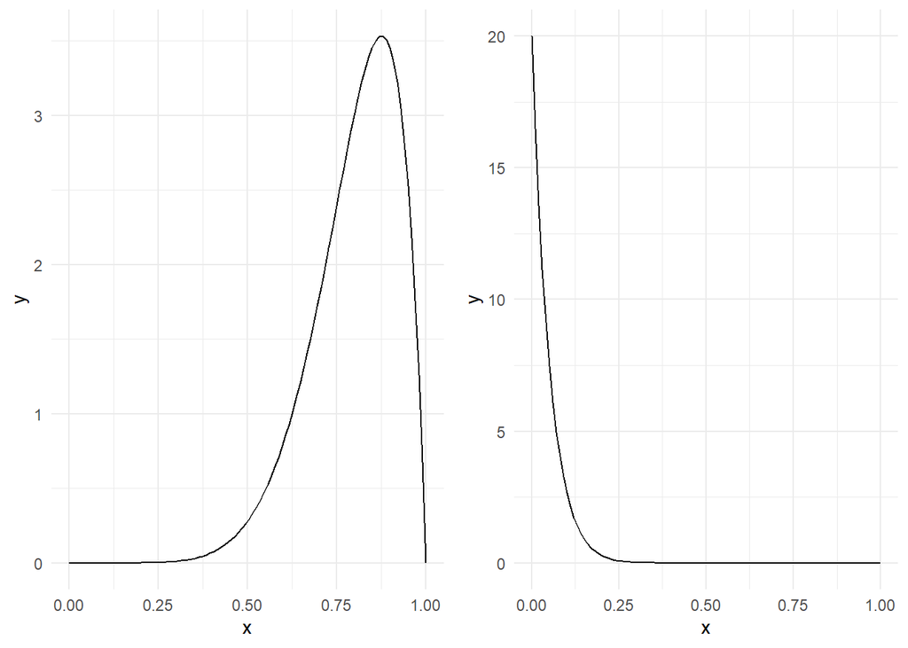

```r
x <- seq(0,1,length.out=100)

ndakota <- tibble(x=x,y=dbeta(x, 8, 2))
louis <- tibble(x=x,y=dbeta(x, 1, 20))

ndplot <- ndakota |> ggplot(aes(x,y)) + geom_line() + theme_minimal()
louisplot <- louis |> ggplot(aes(x,y)) + geom_line() + theme_minimal()

ggarrange(
  ndplot,
  louisplot,
  nrow=1,
  ncol=2
)
```

## Exercise 3.10

n=50, y=12

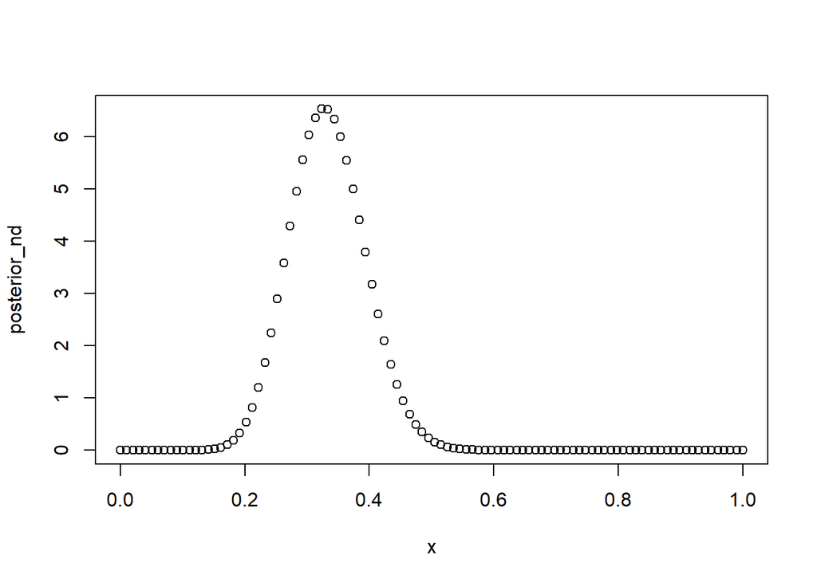

```r
# North Dakota


## Prior model
x <- seq(0,1,length.out=100) # all possible x values
prior_nd <-dbeta(x, 8, 2) # beta model

## Likelihood function
lh_nd <- dbinom(12,50,x) # binom model L(pi{0,1} | y=12)

## Posterior model
posterior_nd <-dbeta(x, 8+12,2+50-12) # posterior model

plot(x,posterior_nd)
```

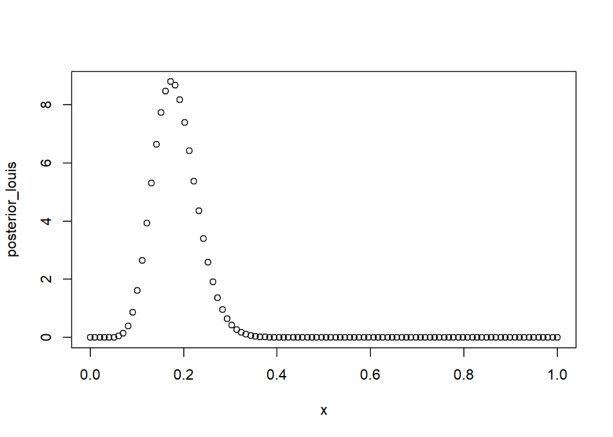

```r
# Louisiana
# Prior
prior_louis <- dbeta(x, 1, 20)
#Lhood function (THE SAME as ND)

## Posterior model
posterior_louis <-dbeta(x, 1+12,20+50-12) # posterior model

plot(x,posterior_louis)
```

North Dakota:

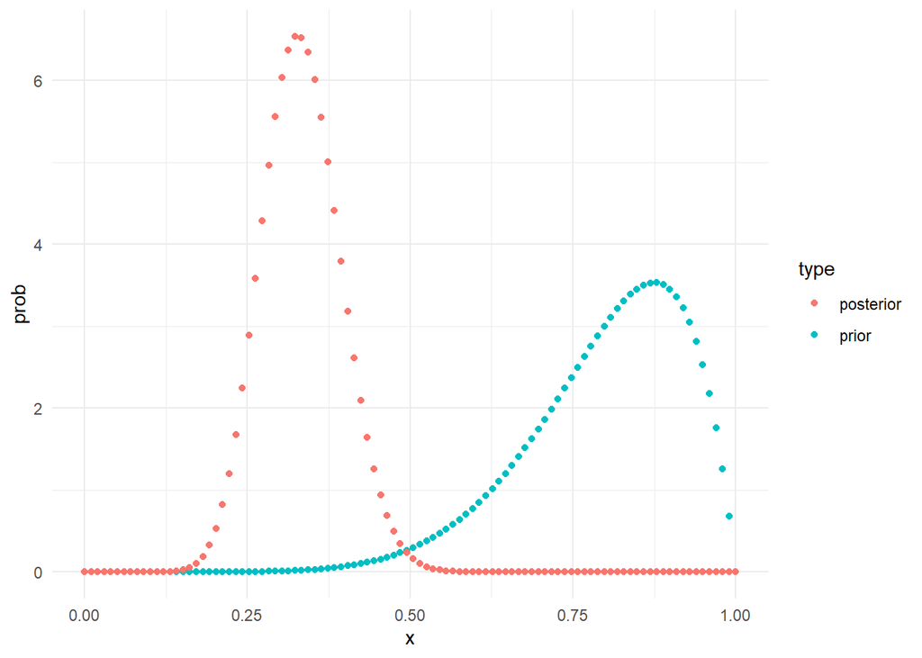

```r
nd_models <-  tibble(x=x, prob=prior_nd, type=rep("prior",100)) |>  add_row(x=x, prob=posterior_nd, type=rep("posterior",100)) |> add_row(x=x, prob=lh_nd, type=rep("lhood",100))

nd_models |> filter(type!="lhood") |> ggplot(aes(x,prob, col=type)) + geom_point() + theme_minimal()
```

The likelihood function:

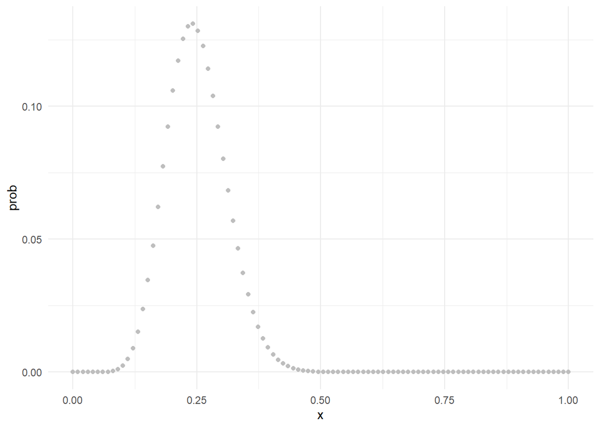

```r
nd_models |> filter(type=="lhood") |> ggplot(aes(x,prob, col=type)) + geom_point(col="gray") + theme_minimal()
```

Louisiana

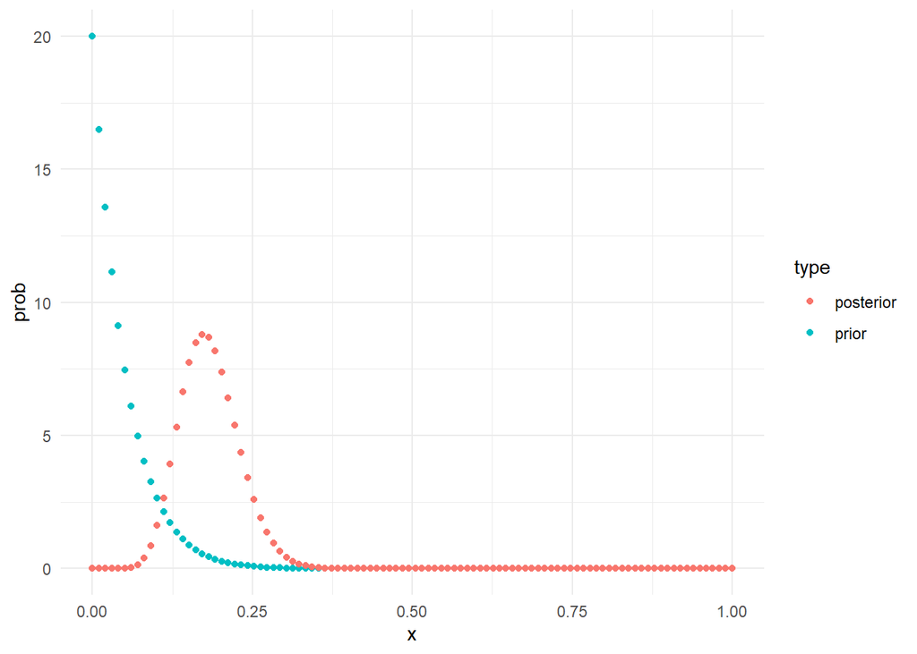

```r
louis_models <-  tibble(x=x, prob=prior_louis, type=rep("prior",100)) |>  add_row(x=x, prob=posterior_louis, type=rep("posterior",100)) |> add_row(x=x, prob=lh_nd, type=rep("lhood",100))

louis_models |> filter(type!="lhood") |> ggplot(aes(x,prob, col=type)) + geom_point() + theme_minimal()
```

The likelihood function:

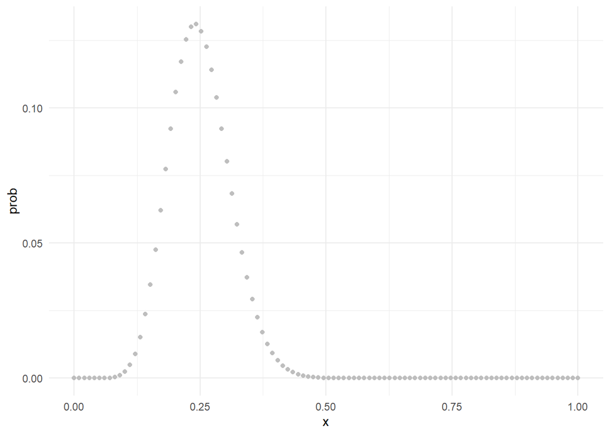

```r
louis_models |> filter(type=="lhood") |> ggplot(aes(x,prob, col=type)) + geom_point(col="gray") + theme_minimal()
```

3. The Louisiana salesman’s prediction was closer to the pdf we obtained after our survey, so he might not be that surprised. On the other hand, the North Dakota salesman had a very different prediction (mean arouund 80%)!

## Exercise 3.11

mean=1/4 mode=5/22

```r
1/alfa(1/4)
```

```
## [1] 3
```

```r
# Alfa equals .33 times B, or B equals 3 times a (B=3a)
a <- seq(1,100,1)
b <- a*3

modal <-  moda(a,b)
media <- mean(a,b)
df <-  tibble(alfa=a, beta=b, mode=modal, mean=media)

df |> filter(mode>.22 & mode<=5/22)
```

```
## # A tibble: 2 x 4
##    alfa  beta  mode  mean
##   <dbl> <dbl> <dbl> <dbl>
## 1     5    15 0.222  0.25
## 2     6    18 0.227  0.25
```

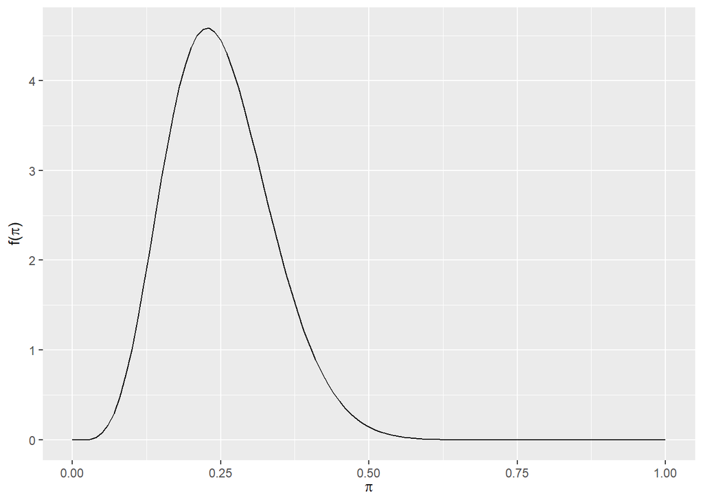

```r
plot_beta(6,18)
```

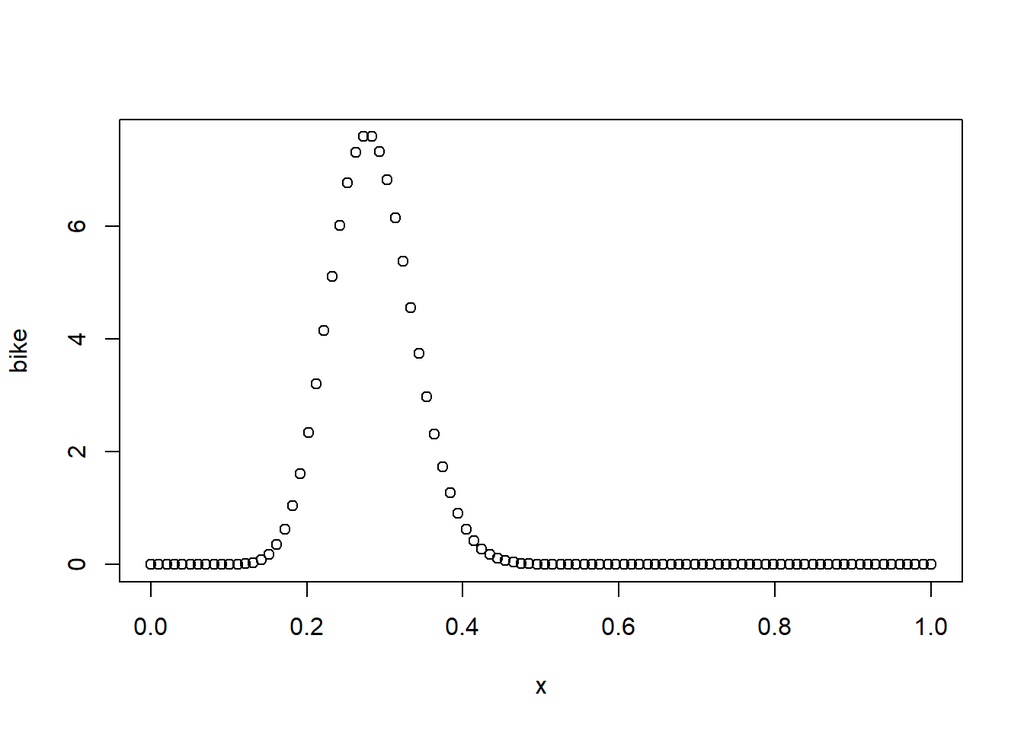

```r
bike <- dbeta(x, 6+15,18+50-15) # posterior model
plot(x, bike)
```

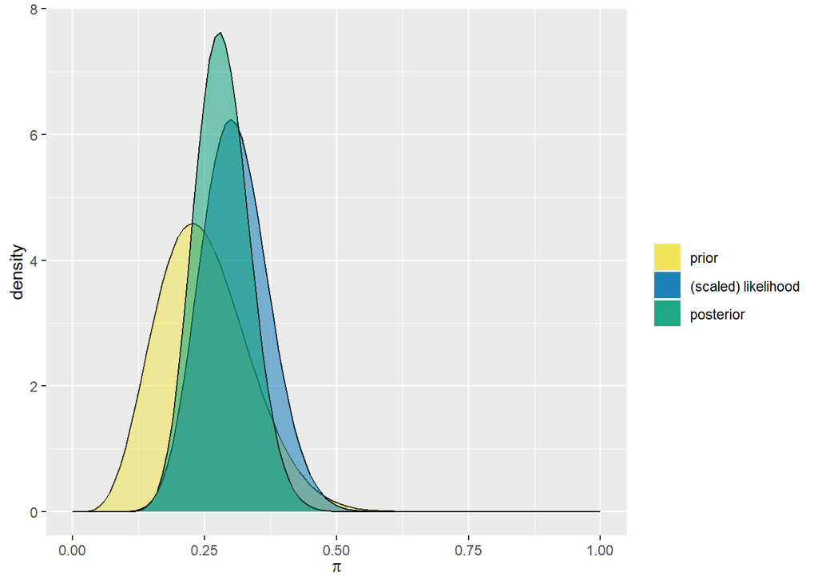

```r
plot_beta_binomial(6,18,15,50)
```

```r
post <- summarize_beta_binomial(6,18,15,50)

post |> filter(model=="posterior")
```

```
##       model alpha beta      mean      mode         var         sd
## 1 posterior    21   53 0.2837838 0.2777778 0.002710007 0.05205773
```

4. The posterior is skewed to the right with respect to the prior and it also reduces the variation observed in the prior (.05 vs .08). On the other hand, the posterior is closer to the observed data (likelihood). Thus, it seems like the observed data outweighed the prior.

## Exercise 3.12

1. Using Steve’s method:

```r
p <- .15
n <- 110

alpha <- p*n
beta <- n*(1-p)
quantile(rbeta(1000, alpha, beta), c(.05,.95))
```

```
##         5%        95%
## 0.09639954 0.20986948
```

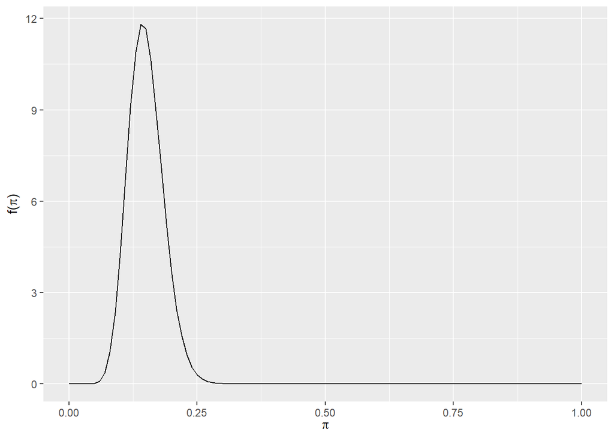

```r
plot_beta(alpha,beta)
```

```r
summarize_beta(alpha,beta)
```

```
##   mean      mode         var         sd
## 1 0.15 0.1435185 0.001148649 0.03389172
```

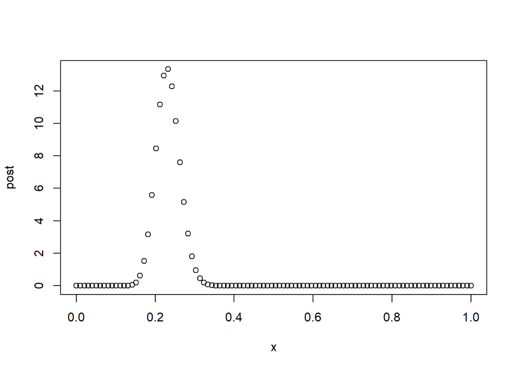

```r
x <- seq(0,1,length.out=100) # all possible x values
post <- dbeta(x,alpha+30,beta+90-30)

plot(x,post)
```

```r
post <- summarize_beta_binomial(alpha,beta,y = 30,90)

post |> filter(model=="posterior")
```

```
##       model alpha  beta   mean     mode          var         sd
## 1 posterior  46.5 153.5 0.2325 0.229798 0.0008877799 0.02979563
```

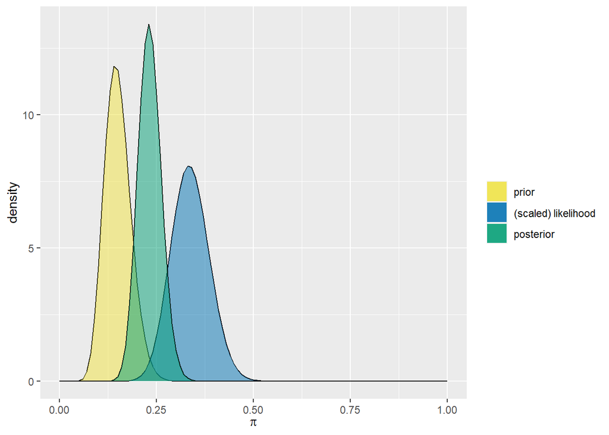

```r
plot_beta_binomial(alpha,beta,30,90)
```

The posterior is skewed to the right of the upper limit of the prior,so it is relatively close. This means that the smaller SD of the prior “pulled” the posterior close to the prior. However, the observed data was also relatively important, so that is why the posterior is in the middle.